# Covid Politics and Concern Statistics Pre-processing and EDA

The following document looks at analyzing the US sentiment on how president Joe Biden and former president Donald Trump have handled the Covid-19 pandemic and how concerned US citizens are with Covid-19 regarding getting infected and its affect on the economy. Data sets were taken from FiveThirtyEight, a statistical news-paper site.

**Data Sources:**

- covid_approval_polls_adjusted.csv
- covid_approval_toplines.csv
- covid_concern_toplines.csv.

**Below is a list of variables that were of importance:**

- subject - the president at the time (Trump/Biden).
- modeldate - the date that FiveThirtyEight created their weighted average of approvals. A full continuous range of dates from the beginning of the pandemic to June 2022.
- pollster - the entity that conducted the poll.
- startdate - the start date of the poll conducted.
- enddate - the end date of the poll conducted.
- approve_adjusted - a weighted approval rating (out of 100).
- disappove_adjusted - a weighted disapproval rating (out of 100).

```r
library(tidyverse)
```

#### Reading in data

```r
polls_adjusted <-
  readr::read_csv('covid_approval_polls_adjusted.csv')
```

#### Grouping by subject and creating new column which is the mean of approve_adjusted

```r
polls_adjusted <- polls_adjusted %>%
  dplyr::group_by(subject) %>%
  dplyr::mutate(average_approval = mean(approve_adjusted, na.rm = T)) %>%
  dplyr::ungroup()
```

#### Creating a graph of the adjusted approval ratings

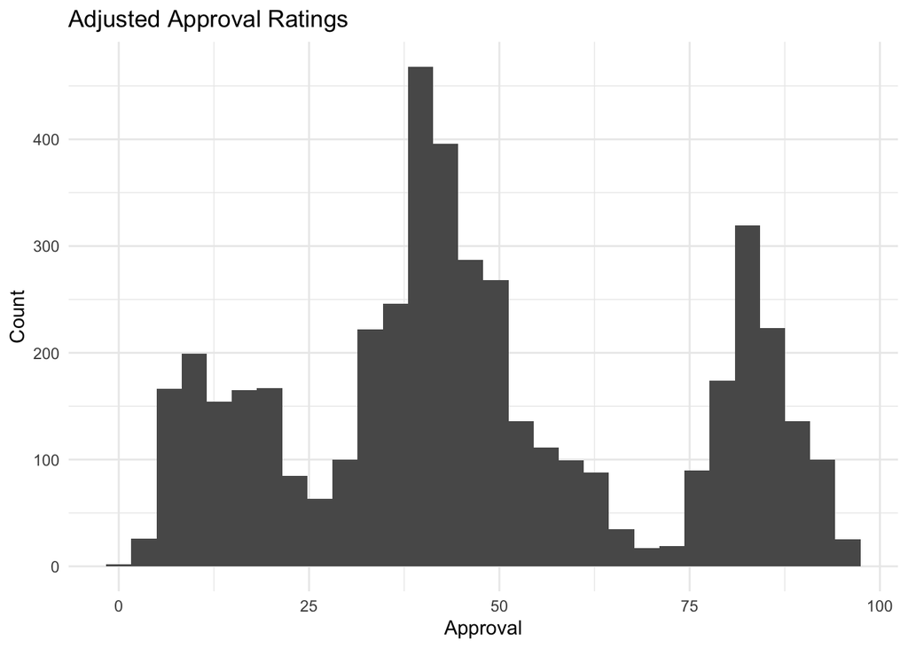

```r
approval_graph <- polls_adjusted %>%
  ggplot(aes(x = approve_adjusted)) +
  geom_histogram() +
  labs(x = 'Approval',
       y = 'Count',
       title = 'Adjusted Approval Ratings') +
  theme_minimal()
```

#### Splitting the graph to display Biden and Trump’s individual ratings

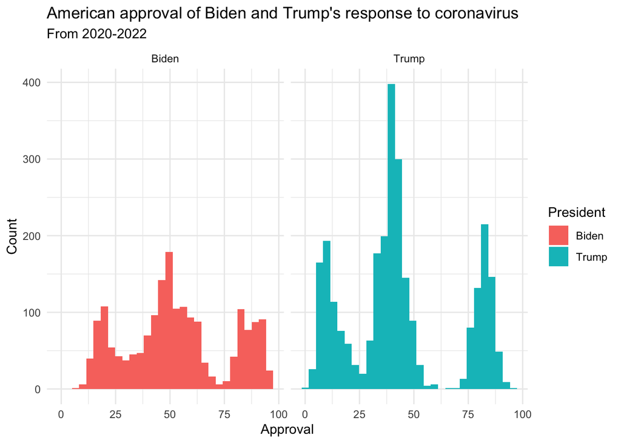

```r
approval_graph_facet <- polls_adjusted %>%
  filter(subject == 'Biden' | subject == 'Trump') %>%
  ggplot(aes(x = approve_adjusted, fill = subject)) +
  geom_histogram() +
  facet_wrap(~subject)+
  labs(
    x = "Approval",
    y = "Count",
    fill = "President",
    title = "American approval of Biden and Trump's response to coronavirus",
    subtitle = "From 2020-2022"
  ) +
  theme_minimal()
```

#### Adding a vertical line to show the mean of both Biden and Trump’s approvals

```r
mean_line <- approval_graph_facet +
  geom_vline(aes(xintercept = average_approval), linetype = 'dashed')
```

#### Changing the represented colors in the graph to match Biden and Trump’s respective party colors

```r
approval_final <- mean_line +
  scale_fill_manual(values = c("#008FD5", "#FF2700")) +
  theme(legend.position = "bottom")
```

#### Creating a column which converts enddate to a ‘date’ data type, creating a column which is the approve_adjusted divided by 100, filtering the data so party column only contains Democrats, Republicans, and Independents

```r
polls_q3 <- polls_adjusted %>%
  mutate(end_date = lubridate::mdy(enddate)) %>%
  mutate(approve_fraction = approve_adjusted / 100) %>%
  filter(party == 'D' | party == 'R' | party == 'I')
```

#### Reading in toplines data

```r
toplines <- readr::read_csv('covid_approval_toplines.csv')
```

#### Filtering subject to only include Biden, party to only include D/R/I

```r
toplines_biden <- toplines %>%
  filter(subject == 'Biden') %>%
  filter(party == 'D' | party == 'R' | party == 'I') %>%
  mutate(model_date = lubridate::mdy(modeldate))
```

#### Creating a new column which is equal to Democrats, Republicans, and Independents if party is D, R and I respectively. Creating a new column which is the fraction of approve_estimate column

```r
toplines_biden <- toplines_biden %>%
  mutate(party_description = ifelse(
    party == 'D',
    'Democrats',
    ifelse(
      party == 'R',
      'Republicans',
      ifelse(party == 'I', 'Independents', 0)
    )
  )) %>%
  mutate(approve_estimate_frac = approve_estimate / 100)
```

#### Visualizing the changes in Biden’s approval rating by political party since his inauguration

```r
library(ggrepel)
library(scales)
library(lubridate)
```

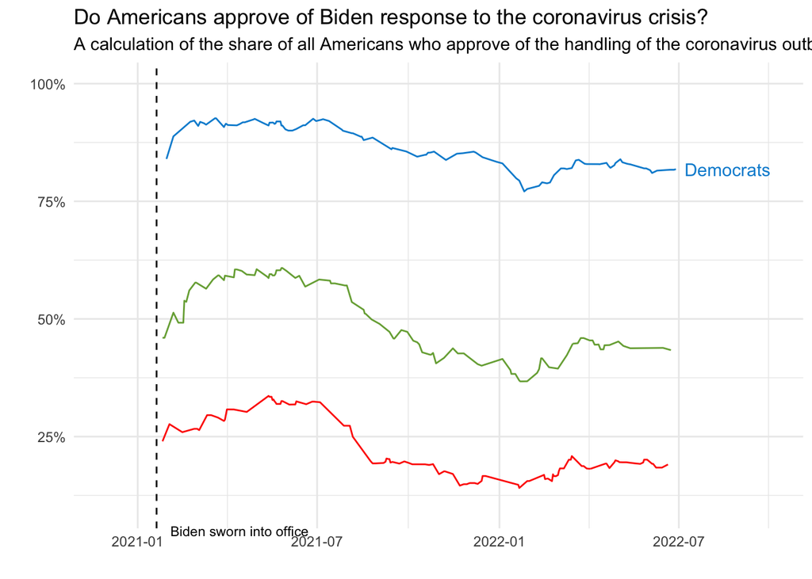

```r
final_graph<-toplines_biden %>%
  mutate(label = ifelse(model_date == max(model_date),
                        party_description, NA_character_)) %>%
  ggplot(aes(x=model_date, y=approve_estimate_frac, color=party)) +
  geom_line() +
  geom_text_repel(aes(label = label),
                  nudge_x = 10, na.rm = T,
                  xlim = as_date(c("2022-07-01", "2022-10-01"))) +
  geom_vline(aes(xintercept = as_date("2021-01-20")), linetype = "dashed")+
  annotate("text", x = as_date("2021-01-20"), y = 0.05,
           label = "Biden sworn into office", size = 3,
           hjust = -0.1) +
  scale_color_manual(values = c("#008FD5", "#77AB43", "#FF2700")) +
  scale_y_continuous(labels = scales::percent) +
  coord_cartesian(ylim = c(.1,1), clip = "off") +
  scale_x_date(limits = c(as_date("2020-12-01"), as_date("2022-10-01"))) +
  labs(title="Do Americans approve of Biden response to the coronavirus crisis?",
       subtitle= "A calculation of the share of all Americans who approve of the handling of the coronavirus outbreak",
       x="",y="", fill="") +
  theme_minimal() +
  theme(legend.position = "none")
```

#### Reading in covid concern data

```r
covid_concern <- read_csv('covid_concern_toplines.csv')
```

#### Reformatting modeldate column into mdy

```r
covid_concern <- covid_concern %>%
  mutate(modeldate = mdy(modeldate))
```

#### Arranging very_estimate column in descending order

```r
covid_concern %>%
  arrange(desc(very_estimate))
```

```
## # A tibble: 1,496 × 8
##    subject         modeldate  party very_estim…¹ somew…² not_v…³ not_a…⁴ times…⁵
##    <chr>           <date>     <chr>        <dbl>   <dbl>   <dbl>   <dbl> <chr>
##  1 concern-economy 2020-03-29 all           63.4    25.7    6.82    3.48 17:45:…
##  2 concern-economy 2020-05-19 all           58.1    29.7    7.97    2.99 23:55:…
##  3 concern-economy 2020-04-20 all           57.9    29.6    8.66    2.87 19:15:…
##  4 concern-economy 2020-08-04 all           57.8    29.9    8.16    2.67 20:05:…
##  5 concern-economy 2020-08-05 all           57.4    30.2    8.22    2.74 18:45:…
##  6 concern-economy 2020-08-17 all           57.2    29.8    8.52    2.89 22:45:…
##  7 concern-economy 2020-07-28 all           57.2    30.7    8.24    2.37 07:10:…
##  8 concern-economy 2020-04-14 all           57.2    29.7    8.79    3.20 19:35:…
##  9 concern-economy 2020-04-13 all           57.2    29.8    8.81    3.07 19:05:…
## 10 concern-economy 2020-04-30 all           57.1    29.8    8.64    3.25 15:45:…
## # … with 1,486 more rows, and abbreviated variable names ¹very_estimate,
## #   ²somewhat_estimate, ³not_very_estimate, ⁴not_at_all_estimate, ⁵timestamp
```

#### Changing level of concern estimates into fractions

```r
covid_concern <- covid_concern %>%
  mutate(very_estimate = very_estimate/100) %>%
  mutate(somewhat_estimate = somewhat_estimate/100) %>%
  mutate(not_very_estimate = not_very_estimate/100) %>%
  mutate(not_at_all_estimate = not_at_all_estimate/100)
```

#### Adding a column that cleans up the classification of what type of concern it is.

```r
covid_concern <- covid_concern %>%
  mutate(concern = ifelse(subject == 'concern-economy', 'Concerned About Economy',ifelse(subject == 'concern-infected', 'Concerned About Getting Infected', 0)))
```

#### Visualizing the concern level about the economy and also getting infected

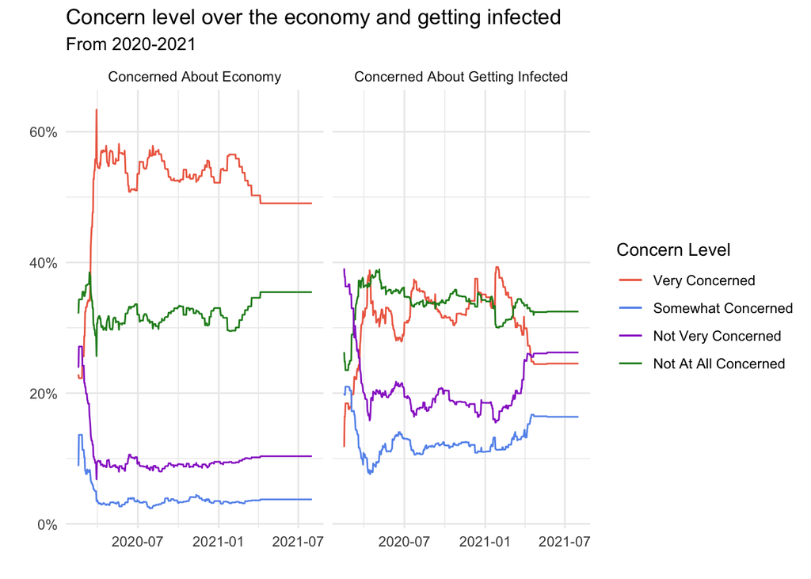

```r
concern_level_by_type <- covid_concern %>%
  ggplot(aes(x = modeldate)) +
  facet_wrap( ~ concern) +
  geom_line(aes(y = very_estimate, color = 'coral2')) +
  geom_line(aes(y = somewhat_estimate, color = 'forestgreen')) +
  geom_line(aes(y = not_very_estimate, color = 'darkorchid')) +
  geom_line(aes(y = not_at_all_estimate, color = 'cornflowerblue')) +
  scale_y_continuous(labels = scales::percent)+
  scale_color_manual(
    name = 'Concern Level',
    values = c('coral2' = 'coral2', 'forestgreen' =
                 'forestgreen', 'darkorchid' =
                 'darkorchid', 'cornflowerblue' =
                 'cornflowerblue'),
    labels = c('Very Concerned', 'Somewhat Concerned', 'Not Very Concerned', 'Not At All Concerned')
  ) +
  theme_minimal() +
  scale_x_date(limits = c(as.Date("2020-02-15"), as.Date("2021-08-01"))) +
  labs( x = '',
        y = '',
        title = 'Concern level over the economy and getting infected',
        subtitle = 'From 2020-2021')
```

#### Visualizing when the concern level about the economy peaked

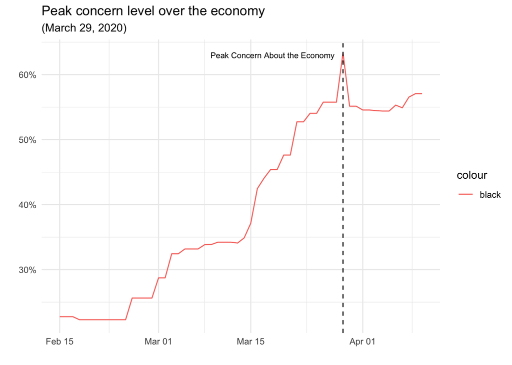

```r
concern_peak_economy <- covid_concern %>%
  filter(subject == 'concern-economy') %>%
  ggplot(aes(x = modeldate)) +
  geom_line(aes(y = very_estimate, color = 'black')) +
  scale_y_continuous(labels = scales::percent) +
  geom_vline(aes(xintercept = as.numeric(as.Date("2020-03-29"))), linetype = 'dashed') +
  scale_x_date(limits = c(as.Date("2020-02-15"), as.Date("2020-04-10"))) +
  labs( x = '',
        y = '',
        title = 'Peak concern level over the economy',
        subtitle = '(March 29, 2020)') +
  annotate(
    "text",
    x = as.Date("2020-03-07"),
    y = .63,
    label = "Peak Concern About the Economy",
    size = 2.80,
    hjust = -0.1) +
  theme_minimal()
```

#### Visualizing when the concern level about getting infected peaked

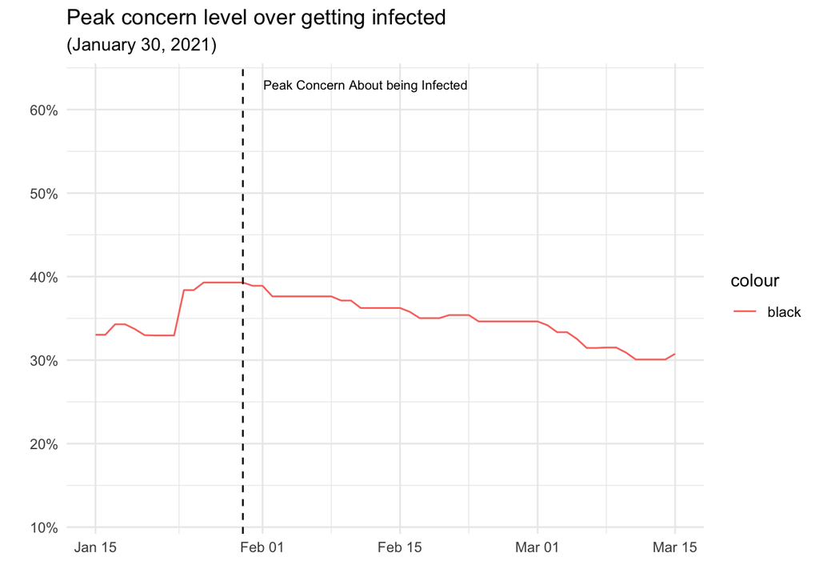

```r
concern_peak_infected <- covid_concern %>%
  filter(subject == 'concern-infected') %>%
  ggplot(aes(x = modeldate)) +
  geom_line(aes(y = very_estimate, color = 'black')) +
  scale_y_continuous(labels = scales::percent) +
  geom_vline(aes(xintercept = as.numeric(as.Date("2021-01-30"))), linetype = 'dashed') +
  scale_x_date(limits = c(as.Date("2021-01-15"), as.Date("2021-03-15"))) +
  labs( x = '',
        y = '',
        title = 'Peak concern level over getting infected',
        subtitle = '(January 30, 2021)') +
  annotate(
    "text",
    x = as.Date("2021-01-30"),
    y = .63,
    label = "Peak Concern About being Infected",
    size = 2.80,
    hjust = -0.1) +
  theme_minimal()
```

#### Filtering subject to only be about getting infected

```r
infected_concern <- covid_concern %>%
  filter(subject == 'concern-infected')
```

#### Visualizing the approval rating of the president’s handling of Covid-19

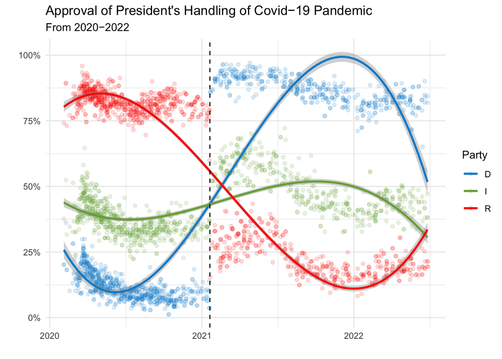

```r
polls_q3 %>%
  ggplot(aes(x = end_date, y = approve_fraction, color = party, se = 3), se = 3) +
  geom_point(alpha = .15, se = 3) +
  scale_color_manual(values = c("#008FD5", "#77AB43", "#FF2700")) +
  geom_smooth(method = lm, formula = y ~ splines::bs(x, 3.5),span = .3, se = 3) +
  scale_y_continuous(labels = scales::percent) +
  theme_minimal() +
  geom_vline(aes(xintercept = as.numeric(as.Date("2021-01-20"))), linetype = 'dashed') +
  labs(
    x = ' ',
    y = ' ',
    title = "Approval of President's Handling of Covid−19 Pandemic",
    subtitle = "From 2020−2022",
    color = 'Party'
  )
```